# Data Analysis in R

University of Wisconsin-Madison

## Check your data

- **Quantitative** data is information about quantities; that is, information that can be measured and written down with numbers. *Example*: x-axis = 1.5, 5.6, 12.8, 26.7. 39.4, 45.1
  - Proceed with regression
  - Numeric or integer
- **Qualitative** data is information about qualities; information that can’t actually be measured. *Example*: x-axis = Pursuit, Roundup, Callisto
  - Proceed with ANOVA
  - Factor

## Quantitative data

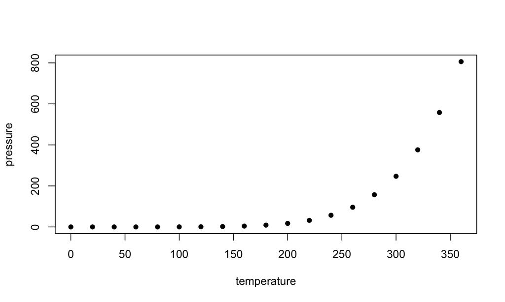

## Qualitative data

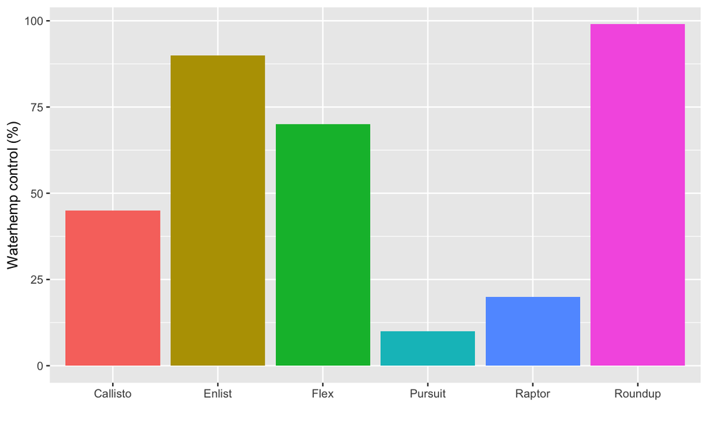

## The ANOVA Test

- A way to find if experiment results are significant. It helps you to figure out if you need to reject the null hypothesis or accept the alternate hypothesis
- Test groups to see if there’s a difference between them
  - A group of weed scientists are trying different herbicides for Palmer amaranth control. You want to see if one herbicide is better than others
  - A company has 20 industrial hemp varieties from outside United States. They want to know which ones performed better in Wisconsin
  - Students from different colleges take the same exam. You want to see if one college outperforms the other

## Hypotheses

- The intent of hypothesis testing is formally examine two opposing conjectures (hypotheses), H0 and HA
- These two hypotheses are mutually exclusive and exhaustive so that one is true to the exclusion of the other
- We accumulate evidence - collect and analyze sample information - for the purpose of determining which of the two hypotheses is true and which of the two hypotheses is false

## The Null and Alternative Hypothesis

- The null hypothesis, H0:
  - States the assumption (numerical) to be tested
  - Begin with the assumption that the null hypothesis is TRUE
  - Always contains the ‘=’ sign
- The alternative hypothesis, Ha:
  - Is the opposite of the null hypothesis
  - Challenges the status quo
  - Never contains just the ‘=’ sign
  - Is generally the hypothesis that is believed to be true by the researcher

## One and Two Sided Tests

- Hypothesis tests can be one or two sided (tailed)
- One tailed tests are directional:

## P-values

- Calculate a test statistic in the sample data that is relevant to the hypothesis being tested
- After calculating a test statistic we convert this to a P- value by comparing its value to distribution of test statistic’s under the null hypothesis
- Measure of how likely the test statistic value is under the null hypothesis

  P-value \(\leq \alpha\) \(\rightarrow\) Reject H0 at level \(\alpha\)

## When To Reject H0

- Level of significance, \(\alpha\): Specified before an experiment to define rejection region (usually 0.05)
- Rejection region: set of all test statistic values for which H0 will be rejected

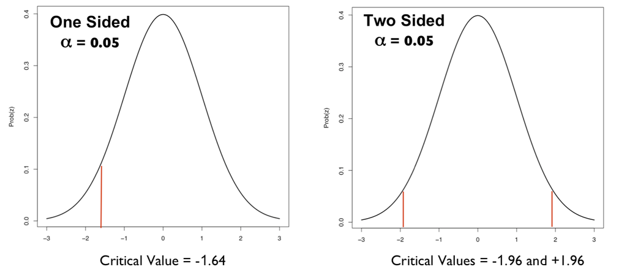

## Assumptions of ANOVA

- Independence
- Normality
- Homogeneity of variances (aka, Homoscedasticity)

## Parametric and Non-Parametric Tests

- **Parametric Tests**: Relies on theoretical distributions of the test statistic under the null hypothesis and assumptions about the distribution of the sample data (i.e., normality)
- **Non-Parametric Tests**: Referred to as “Distribution Free” as they do not assume that data are drawn from any particular distribution

## Testing normality

- Using the data **barley** from package *lattice*

```r
library(lattice)
sample_n(barley, 5)
```

```
##      yield  variety year         site
## 1 34.70000 Peatland 1931 Grand Rapids
## 2 33.06666  No. 475 1931       Duluth
## 3 46.93333    Trebi 1931    Crookston
## 4 55.20000  Glabron 1931       Waseca
## 5 29.86667 Peatland 1931       Morris
```

- A data frame with 120 observations on the following 4 variables
  - Yield (averaged across three blocks) in bushels/acre.
  - Variety (factor) with levels “Svansota”, “No. 462”, “Manchuria”, “No. 475”, “Velvet”, “Peatland”, “Glabron”, “No. 457”, “Wisconsin No. 38”, “Trebi”.
  - Year (factor) with levels 1931 and 1932
  - Site (factor) with 6 levels: “Grand Rapids”, “Duluth”, “University Farm”, “Morris”, “Crookston”, “Waseca”

## Visual plots

- Density plot: the density plot provides a visual judgment about whether the distribution is bell shaped.

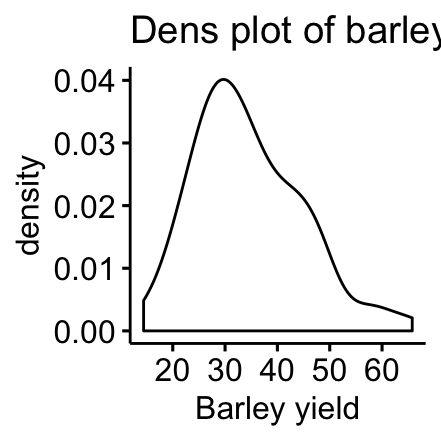

```r
ggdensity(barley$yield,
          main = "Dens plot of barley yield",
          xlab = "Barley yield")
```

## Q-Q plot

- Q-Q plot: Q-Q plot (or quantile-quantile plot) draws the correlation between a given sample and the normal distribution. A 45-degree reference line is also plotted.

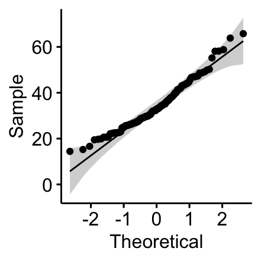

```r
ggqqplot(barley$yield)
```

## Normality test

```r
library(nortest)
pearson.test(barley$yield)
```

```
##
##  Pearson chi-square normality test
##
## data:  barley$yield
## P = 16.5, p-value = 0.1236
```

- From the output, the p-value > 0.05 implying that the distribution of the data are not significantly different from normal distribution. In other words, we can assume the normality.
- Other tests of normality (Shapiro-Wilk)

## Data transformation

- Assuming data (barley yield) is non-gaussean (non-normal)
- Load the package [*bestNormalize*](https://cran.r-project.org/web/packages/bestNormalize/bestNormalize.pdf)

```r
#install.packages("bestNormalize") # if needed
library(bestNormalize)
```

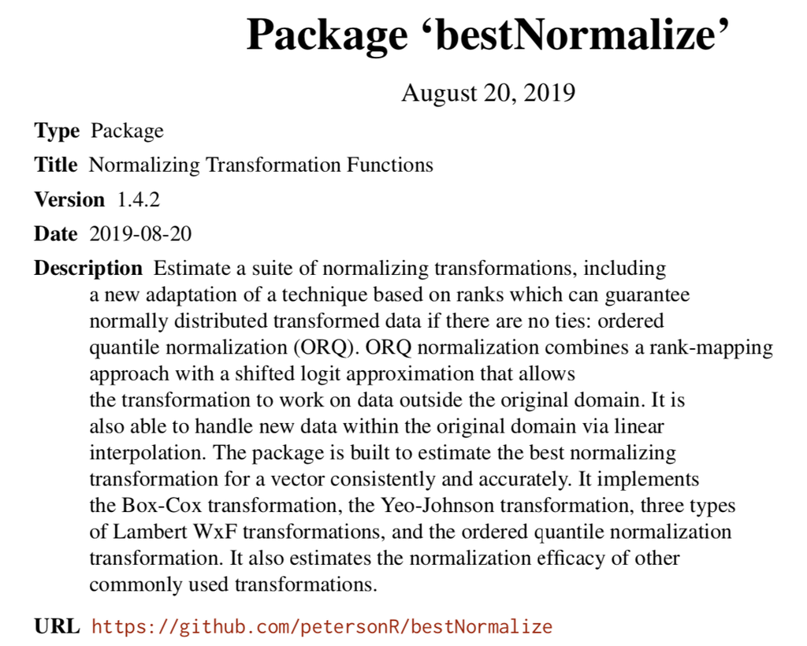

## Transforming the data

```r
data <- bestNormalize(barley$yield, loo = TRUE)
```

```r
data
```

```
## Best Normalizing transformation with 120 Observations
##  Estimated Normality Statistics (Pearson P / df, lower => more normal):
##  - No transform: 1.5
##  - Box-Cox: 0.4818
##  - Log_b(x+a): 0.4818
##  - sqrt(x+a): 0.9909
##  - exp(x): 136.9621
##  - arcsinh(x): 0.4818
##  - Yeo-Johnson: 0.4818
##  - orderNorm: 0.1212
## Estimation method: Out-of-sample via leave-one-out CV
##
## Based off these, bestNormalize chose:
## orderNorm Transformation with 120 nonmissing obs and ties
##  - 114 unique values
##  - Original quantiles:
##     0%    25%    50%    75%   100%
## 14.433 26.875 32.867 41.400 65.767
```

## Visual plots of transformed yield date

- Density plot: the density plot provides a visual judgment about whether the distribution is bell shaped (transformed data)

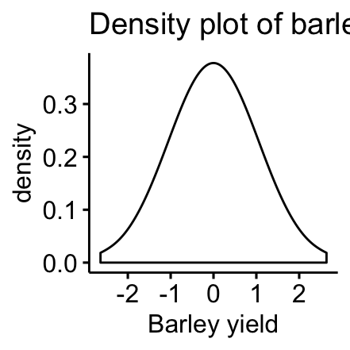

```r
ggdensity(data$x.t,
          main = "Density plot of barley yield",
          xlab = "Barley yield")
```

## Q-Q plot of transformed yield date

- Q-Q plot: Q-Q plot (or quantile-quantile plot) draws the correlation between a given sample and the normal distribution. A 45-degree reference line is also plotted

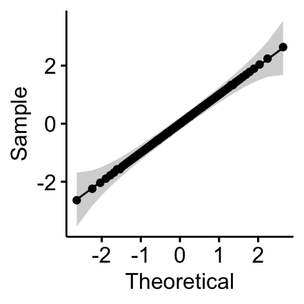

```r
ggqqplot(data$x.t)
```

## Normality test after data transformation

```r
pearson.test(data$x.t)
```

```
##
##  Pearson chi-square normality test
##
## data:  data$x.t
## P = 0.4, p-value = 1
```

- From the output, the p-value > 0.05 implying that thedistribution of the data are not significantly different from normal distribution. In other words, we can assume the normality.

## Post-Hoc ANOVA

- Use package: [lme4](https://cran.r-project.org/web/packages/lme4/lme4.pdf)

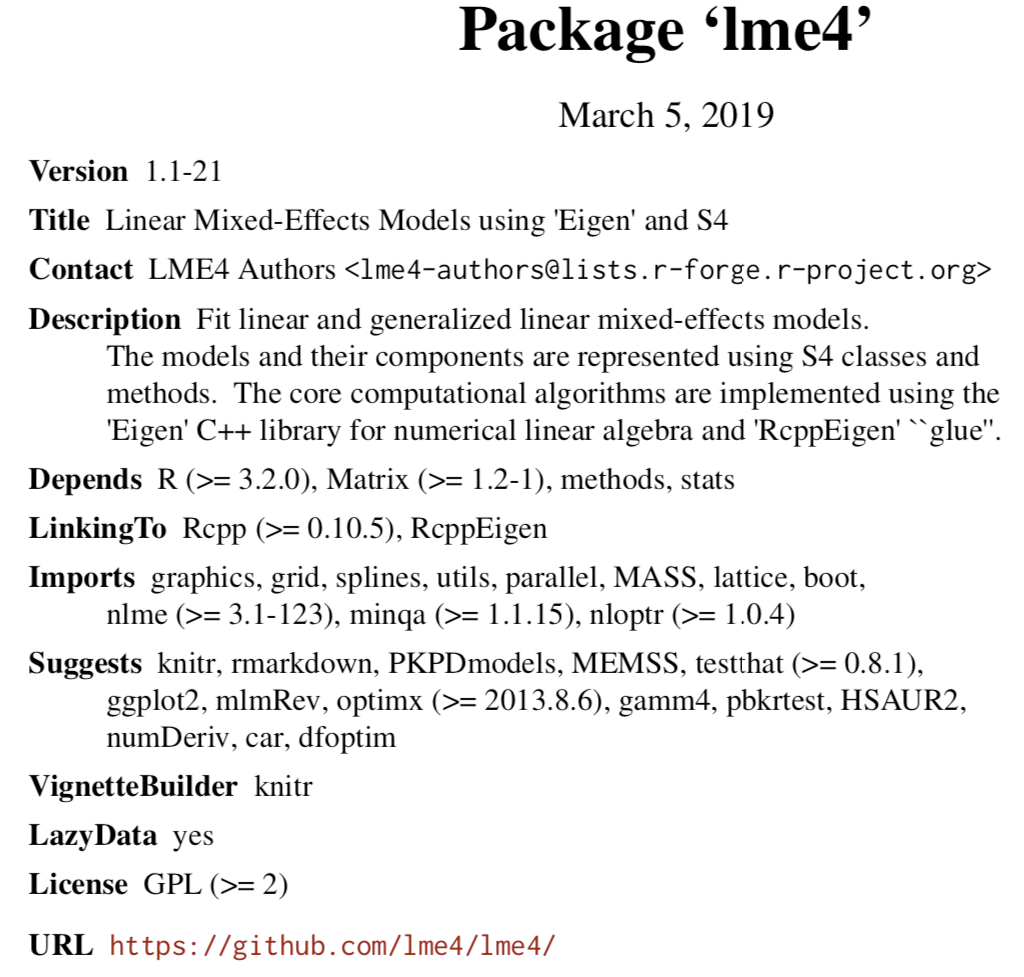

## Post-Hoc ANOVA

Packages

```r
library(lme4) # model
library(emmeans) # anova
library(lmerTest) # lsmeans
library(lsmeans)
```

## Model

```r
fit <- lmer(yield ~ variety * site + (1|year), data=barley)
```

## Summary

```r
summary(fit, ddf="Kenward-Roger")
```

```
## Linear mixed model fit by REML. t-tests use Kenward-Roger's method [
## lmerModLmerTest]
## Formula: yield ~ variety * site + (1 | year)
##    Data: barley
##
## REML criterion at convergence: 449.8
##
## Scaled residuals:
##    Min     1Q Median     3Q    Max
## -1.877 -0.491  0.000  0.491  1.877
##
## Random effects:
##  Groups   Name        Variance Std.Dev.
##  year     (Intercept) 13.29    3.645
##  Residual             50.35    7.096
## Number of obs: 120, groups:  year, 2
##
## Fixed effects:
##                                             Estimate Std. Error      df
## (Intercept)                                  23.1500     5.6406 16.7949
## varietyNo. 462                               -0.7333     7.0955 59.0000
## varietyManchuria                              4.4000     7.0955 59.0000
## varietyNo. 475                               -5.6833     7.0955 59.0000
## varietyVelvet                                 4.4833     7.0955 59.0000
## varietyPeatland                               7.5833     7.0955 59.0000
## varietyGlabron                               -1.3667     7.0955 59.0000
## varietyNo. 457                                2.6667     7.0955 59.0000
## varietyWisconsin No. 38                       4.4167     7.0955 59.0000
## varietyTrebi                                  2.0500     7.0955 59.0000
## siteDuluth                                    0.8167     7.0955 59.0000
## siteUniversity Farm                           8.1333     7.0955 59.0000
## siteMorris                                    7.2500     7.0955 59.0000
## siteCrookston                                 7.4000     7.0955 59.0000
## siteWaseca                                   19.7667     7.0955 59.0000
## varietyNo. 462:siteDuluth                     2.0667    10.0346 59.0000
## varietyManchuria:siteDuluth                  -2.6000    10.0346 59.0000
## varietyNo. 475:siteDuluth                    11.9333    10.0346 59.0000
## varietyVelvet:siteDuluth                     -4.0667    10.0346 59.0000
## varietyPeatland:siteDuluth                    0.1333    10.0346 59.0000
## varietyGlabron:siteDuluth                     5.1667    10.0346 59.0000
```

[output cut: 87 more lines]

```
## varietyGlabron:siteCrookston                  0.296 0.768539
## varietyNo. 457:siteCrookston                  0.676 0.501684
## varietyWisconsin No. 38:siteCrookston         0.789 0.433306
## varietyTrebi:siteCrookston                    1.174 0.245003
## varietyNo. 462:siteWaseca                     1.301 0.198484
## varietyManchuria:siteWaseca                  -0.613 0.542310
## varietyNo. 475:siteWaseca                     0.676 0.501684
## varietyVelvet:siteWaseca                     -0.357 0.722292
## varietyPeatland:siteWaseca                   -0.817 0.417115
## varietyGlabron:siteWaseca                     0.490 0.625970
## varietyNo. 457:siteWaseca                     0.455 0.650712
## varietyWisconsin No. 38:siteWaseca            1.111 0.271007
## varietyTrebi:siteWaseca                       1.153 0.253691
## ---
## Signif. codes:  0 '***' 0.001 '**' 0.01 '*' 0.05 '.' 0.1 ' ' 1
```

```
##
## Correlation matrix not shown by default, as p = 60 > 12.
## Use print(x, correlation=TRUE)  or
##     vcov(x)        if you need it
```

## ANOVA

```r
anova(fit)
```

```
## Type III Analysis of Variance Table with Satterthwaite's method
##              Sum Sq Mean Sq NumDF DenDF F value   Pr(>F)
## variety      1052.6  116.95     9    59  2.3230  0.02592 *
## site         6633.9 1326.77     5    59 26.3529 6.95e-14 ***
## variety:site 1205.8   26.79    45    59  0.5322  0.98544
## ---
## Signif. codes:  0 '***' 0.001 '**' 0.01 '*' 0.05 '.' 0.1 ' ' 1
```

## Visual interaction

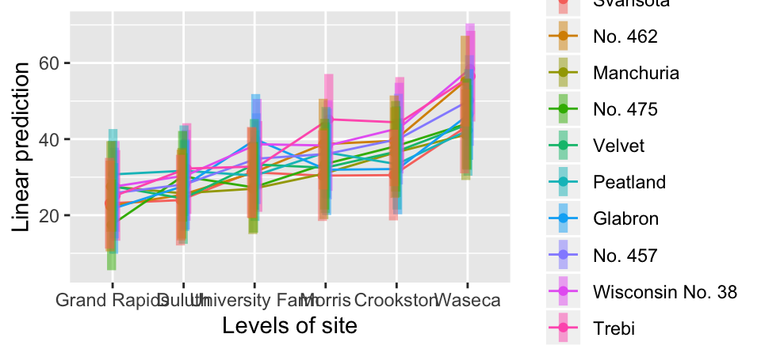

```r
emmip(fit, variety ~ site | site, CIs = TRUE)
```

##

[figure not shown]

```r
plot(emmeans(fit, ~ site | site*variety))
```

## LS Means

- Looking the **site** level (Factor)

```r
lssite<-emmeans(fit, "site", contr="pairwise", adjust="none", type="response")
```

```
## NOTE: Results may be misleading due to involvement in interactions
```

```r
lssite
```

```
## $emmeans
##  site            emmean   SE   df lower.CL upper.CL
##  Grand Rapids      24.9 3.03 1.68     9.21     40.6
##  Duluth            28.0 3.03 1.68    12.28     43.7
##  University Farm   32.7 3.03 1.68    16.95     48.4
##  Morris            35.4 3.03 1.68    19.68     51.1
##  Crookston         37.4 3.03 1.68    21.70     53.1
##  Waseca            48.1 3.03 1.68    32.39     63.8
##
## Results are averaged over the levels of: variety
## Degrees-of-freedom method: kenward-roger
## Confidence level used: 0.95
##
## $contrasts
##  contrast                       estimate   SE df t.ratio p.value
##  Grand Rapids - Duluth             -3.06 2.24 59  -1.366 0.1771
##  Grand Rapids - University Farm    -7.74 2.24 59  -3.447 0.0011
##  Grand Rapids - Morris            -10.47 2.24 59  -4.665 <.0001
##  Grand Rapids - Crookston         -12.49 2.24 59  -5.566 <.0001
##  Grand Rapids - Waseca            -23.18 2.24 59 -10.329 <.0001
##  Duluth - University Farm          -4.67 2.24 59  -2.081 0.0418
##  Duluth - Morris                   -7.40 2.24 59  -3.299 0.0016
##  Duluth - Crookston                -9.42 2.24 59  -4.200 0.0001
##  Duluth - Waseca                  -20.11 2.24 59  -8.963 <.0001
##  University Farm - Morris          -2.73 2.24 59  -1.218 0.2280
##  University Farm - Crookston       -4.75 2.24 59  -2.118 0.0384
##  University Farm - Waseca         -15.44 2.24 59  -6.882 <.0001
##  Morris - Crookston                -2.02 2.24 59  -0.900 0.3716
##  Morris - Waseca                  -12.71 2.24 59  -5.664 <.0001
##  Crookston - Waseca               -10.69 2.24 59  -4.764 <.0001
##
## Results are averaged over the levels of: variety
## Degrees-of-freedom method: kenward-roger
```

## Plot

- Plotting the site *level* (Factor)

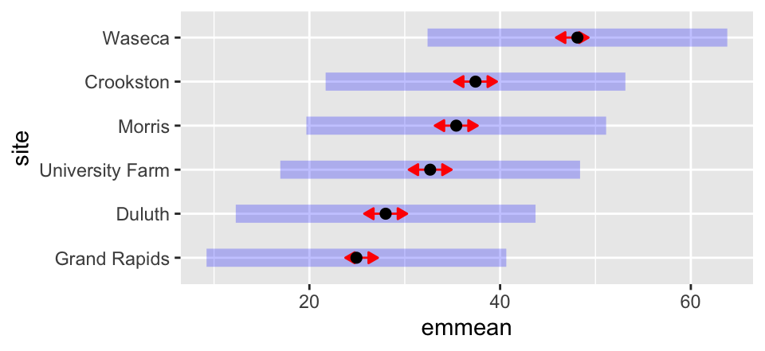

```r
plot(lssite, comparisons =TRUE, adjust="none")
```

## LS Means

- Looking the **variety** level (Factor)

```r
lsvar<-lsmeans(fit, "variety", contr="pairwise", adjust="none", type="response")
```

```
## NOTE: Results may be misleading due to involvement in interactions
```

```r
lsvar
```

```
## $lsmeans
##  variety          lsmean   SE   df lower.CL upper.CL
##  Svansota           30.4 3.29 2.34     18.0     42.7
##  No. 462            35.4 3.29 2.34     23.0     47.7
##  Manchuria          31.5 3.29 2.34     19.1     43.8
##  No. 475            31.8 3.29 2.34     19.4     44.1
##  Velvet             33.1 3.29 2.34     20.7     45.4
##  Peatland           34.2 3.29 2.34     21.8     46.5
##  Glabron            33.3 3.29 2.34     21.0     45.7
##  No. 457            35.8 3.29 2.34     23.5     48.2
##  Wisconsin No. 38   39.4 3.29 2.34     27.0     51.7
##  Trebi              39.4 3.29 2.34     27.0     51.8
##
## Results are averaged over the levels of: site
## Degrees-of-freedom method: kenward-roger
## Confidence level used: 0.95
##
## $contrasts
##  contrast                     estimate  SE df t.ratio p.value
##  Svansota - No. 462           -5.00000 2.9 59 -1.726  0.0896
##  Svansota - Manchuria         -1.08611 2.9 59 -0.375  0.7090
##  Svansota - No. 475           -1.38333 2.9 59 -0.478  0.6347
##  Svansota - Velvet            -2.68333 2.9 59 -0.926  0.3580
##  Svansota - Peatland          -3.80278 2.9 59 -1.313  0.1943
##  Svansota - Glabron           -2.96389 2.9 59 -1.023  0.3104
##  Svansota - No. 457           -5.46945 2.9 59 -1.888  0.0639
##  Svansota - Wisconsin No. 38  -9.01667 2.9 59 -3.113  0.0029
##  Svansota - Trebi             -9.02222 2.9 59 -3.115  0.0028
##  No. 462 - Manchuria           3.91389 2.9 59  1.351  0.1818
##  No. 462 - No. 475             3.61667 2.9 59  1.249  0.2168
##  No. 462 - Velvet              2.31667 2.9 59  0.800  0.4271
##  No. 462 - Peatland            1.19722 2.9 59  0.413  0.6809
##  No. 462 - Glabron             2.03612 2.9 59  0.703  0.4849
##  No. 462 - No. 457            -0.46944 2.9 59 -0.162  0.8718
##  No. 462 - Wisconsin No. 38   -4.01666 2.9 59 -1.387  0.1708
##  No. 462 - Trebi              -4.02221 2.9 59 -1.389  0.1702
##  Manchuria - No. 475          -0.29722 2.9 59 -0.103  0.9186
##  Manchuria - Velvet           -1.59722 2.9 59 -0.551  0.5835
##  Manchuria - Peatland         -2.71667 2.9 59 -0.938  0.3522
##  Manchuria - Glabron          -1.87778 2.9 59 -0.648  0.5193
```

[output cut: 12 more lines]

```
##  Velvet - Wisconsin No. 38    -6.33334 2.9 59 -2.186  0.0328
##  Velvet - Trebi               -6.33888 2.9 59 -2.188  0.0326
##  Peatland - Glabron            0.83889 2.9 59  0.290  0.7731
##  Peatland - No. 457           -1.66667 2.9 59 -0.575  0.5672
##  Peatland - Wisconsin No. 38  -5.21389 2.9 59 -1.800  0.0770
##  Peatland - Trebi             -5.21944 2.9 59 -1.802  0.0767
##  Glabron - No. 457            -2.50556 2.9 59 -0.865  0.3906
##  Glabron - Wisconsin No. 38   -6.05278 2.9 59 -2.090  0.0410
##  Glabron - Trebi              -6.05833 2.9 59 -2.091  0.0408
##  No. 457 - Wisconsin No. 38   -3.54722 2.9 59 -1.225  0.2256
##  No. 457 - Trebi              -3.55277 2.9 59 -1.226  0.2249
##  Wisconsin No. 38 - Trebi     -0.00555 2.9 59 -0.002  0.9985
##
## Results are averaged over the levels of: site
## Degrees-of-freedom method: kenward-roger
```

## LS Means

- Plotting the **variety** level (factor)

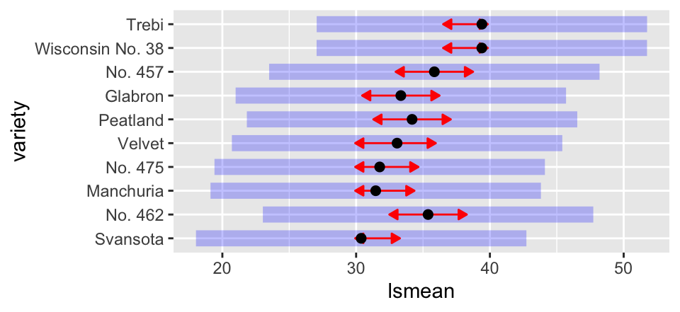

```r
plot(lsvar, comparisons =TRUE, adjust="none")
```